# MSc Statistical overview

# Housekeeping

### Preamble

By Katherine Duchesneau

We are working with the roots Lesion and Mycorrhiza dataset for now.

### R details

This section contains all the necessary details about the R version and package version used to run this Notebook.

- File creation date: 2018-01-27
- R version 3.4.1 (2017-06-30)
- `tidyverse` package version: 1.2.1
- `lme4` package version 1.1.13
- `MASS` package version 7.3.47
- `MuMIn` package version 1.15.6
- `emmeans` package version 0.9.1
- `boot` package version 1.3.20
- `brms` package version 2.0.1
- `loo` package version 1.1.0
- `fitdistrplus` package version 1.0.9

### Load Packages and Functions

```r
library(tidyverse)
library(lme4)
library(MASS)
library(MuMIn)
library(emmeans)
library(boot)
library(brms)
library(loo)
library(fitdistrplus)

# theme_simple() a homemade function from the Colautti lab (2017) to standardize figures
theme_simple <- function (base_size = 16, base_family = "") {
  theme_classic(base_size = base_size, base_family = base_family) %+replace%
    theme(
      axis.text = element_text(colour = "black"),
      axis.title.x = element_text(size=18),
      axis.text.x = element_text(size=16, face= "italic"),
      axis.title.y = element_text(size=18, angle=90),
      axis.text.y = element_text(size=16),
      axis.ticks = element_blank(),
      panel.background = element_rect(fill="white"),
      panel.border = element_blank(),
      plot.title=element_text(face="bold", size=24)
      #      legend.position="none"
    )
}

overdisp_fun <- function(model) {
  ## number of variance parameters in an n-by-n variance-covariance matrix
  vpars <- function(m) {
    nrow(m) * (nrow(m) + 1)/2
  }
  # The next two lines calculate the residual degrees of freedom
  model.df <- sum(sapply(VarCorr(model), vpars)) + length(fixef(model))
  rdf <- nrow(model.frame(model)) - model.df
  # extracts the Pearson residuals
  rp <- residuals(model, type = "pearson")
  Pearson.chisq <- sum(rp^2)
  prat <- Pearson.chisq/rdf
  # Generates a p-value. If less than 0.05, the data are overdispersed.
  pval <- pchisq(Pearson.chisq, df = rdf, lower.tail = FALSE)
  c(chisq = Pearson.chisq, ratio = prat, rdf = rdf, p = pval)
}
```

# Introducing the Data

### Load/ Modify data: Co-occurence

```r
mdata <- read.csv("Assessing_Oct_20.csv",stringsAsFactors=F)
indiv <- mdata$CODE[!mdata$CODE==""]
tdata <- mdata[grep("[0-9]+",mdata$Cross),]
nrow(tdata)/length(indiv)
```

```
## [1] 99.55752
```

```r
# This is not the same because some individuals just had the totals not the cooccurence data
indiv2 <- tdata$CODE[!tdata$CODE==""]
nrow(tdata)/length(indiv2)
```

```
## [1] 100
```

```r
indiv2 <- data.frame(indiv2)
indiv2 <- mefa:::rep.data.frame(indiv2,each=100)
fdata <- cbind(indiv2,tdata)
fdata <- fdata[,-c(2,3,4,9,14,17,18)]

# Cleaning up the occurence data
fdata[is.na(fdata)] <- 0
fdata$Lesion<-rowSums(fdata[,2:4])
fdata[fdata$Lesion>1,]
```

| indiv2 | Decay | Pathogen | Hyphae | None.Path | Arbuscules | Vesicles | M_Hyphae | None.Myc | Herbivory | None.Herb | Lesion |
| --- | --- | --- | --- | --- | --- | --- | --- | --- | --- | --- | --- |

```r
fdata$Mycorrhiza<-rowSums(fdata[,6:8])
fdata[fdata$Mycorrhiza>1,]
```

| indiv2 | Decay | Pathogen | Hyphae | None.Path | Arbuscules | Vesicles | M_Hyphae | None.Myc | Herbivory | None.Herb | Lesion | Mycorrhiza |
| --- | --- | --- | --- | --- | --- | --- | --- | --- | --- | --- | --- | --- |

```r
fdata <- fdata[,-c(2:4,6:8)]

#### Checking data for problems ####

summary(fdata)
```

```
##      indiv2       None.Path           None.Myc           Herbivory
##  10IAH1 :  100   Length:22500       Length:22500       Min.   :0.00000
##  10IAH2 :  100   Class :character   Class :character   1st Qu.:0.00000
##  10ISC1 :  100   Mode  :character   Mode  :character   Median :0.00000
##  10ISC2 :  100                                         Mean   :0.03658
##  10ISC3 :  100                                         3rd Qu.:0.00000
##  10OAH1 :  100                                         Max.   :1.00000
##  (Other):21900
##    None.Herb          Lesion        Mycorrhiza
##  Min.   :0.0000   Min.   :0.000   Min.   :0.0000
##  1st Qu.:1.0000   1st Qu.:0.000   1st Qu.:0.0000
##  Median :1.0000   Median :1.000   Median :1.0000
##  Mean   :0.9631   Mean   :0.622   Mean   :0.5732
##  3rd Qu.:1.0000   3rd Qu.:1.000   3rd Qu.:1.0000
##  Max.   :1.0000   Max.   :1.000   Max.   :1.0000
##
```

```r
fdata$None.Path <- as.integer(fdata$None.Path)
fdata$None.Myc <- as.integer(fdata$None.Myc)
fdata[is.na(fdata)] <- 0


sherb <- fdata$Herbivory+fdata$None.Herb
fdata[sherb!=1,]
```

|  | indiv2 | None.Path | None.Myc | Herbivory | None.Herb | Lesion | Mycorrhiza |
| --- | --- | --- | --- | --- | --- | --- | --- |
| 1573 | 7ISC1 | 0 | 0 | 0 | 0 | 1 | 1 |
| 1587 | 7ISC1 | 0 | 0 | 0 | 0 | 1 | 1 |
| 1729 | 7ISC2 | 1 | 0 | 0 | 0 | 0 | 1 |
| 9107 | 5OSC2 | 1 | 1 | 0 | 0 | 0 | 0 |
| 9154 | 3ISC3 | 1 | 1 | 0 | 0 | 0 | 0 |
| 14441 | 5OAH1 | 0 | 0 | 0 | 0 | 1 | 1 |
| 23150 | 7OCL1 | 0 | 1 | 0 | 0 | 1 | 0 |
| 23253 | 3OMR2 | 1 | 1 | 0 | 0 | 0 | 0 |

```r
fdata[sherb!=1,"None.Herb"]<-1

# Are all the sums equal to 100 for herb?
dframeHerb <- data.frame(counter=NA, Indiv2=NA,Sum=NA)
c <- 1
for (i in unique(fdata$indiv2)){
  dframeHerb[c,] <- NA
  subdata <- fdata[fdata$indiv2==i,]
  dframeHerb$counter[c] <- c
  dframeHerb$Indiv2[c] <- i
  dframeHerb$Sum[c] <- sum(subdata[,"Herbivory"]+subdata[,"None.Herb"])
  subdata <- NA
  c <- c + 1
}
dframeHerb[dframeHerb$Sum!=100,]
```

| counter | Indiv2 | Sum |
| --- | --- | --- |

```r
# Are all the sums equal to 100 for Mycorrhiza?
dframeMyc <- data.frame(counter=NA, Indiv2=NA,Sum=NA)
c <- 1
for (i in unique(fdata$indiv2)){
  dframeMyc[c,] <- NA
  subdata <- fdata[fdata$indiv2==i,]
  dframeMyc$counter[c] <- c
  dframeMyc$Indiv2[c] <- i
  dframeMyc$Sum[c] <- sum(subdata[,"Mycorrhiza"]+subdata[,"None.Myc"])
  subdata <- NA
  c <- c + 1
}
dframeMyc[dframeMyc$Sum!=100,]
```

| counter | Indiv2 | Sum |
| --- | --- | --- |

```r
# Are all the sums equal to 100 for Lesions?
dframeLesion <- data.frame(counter=NA, Indiv2=NA,Sum=NA)
c <- 1
for (i in unique(fdata$indiv2)){
  dframeLesion[c,] <- NA
  subdata <- fdata[fdata$indiv2==i,]
  dframeLesion$counter[c] <- c
  dframeLesion$Indiv2[c] <- i
  dframeLesion$Sum[c] <- sum(subdata[,"Lesion"]+subdata[,"None.Path"])
  subdata <- NA
  c <- c + 1
}
dframeLesion[dframeLesion$Sum!=100,]
```

| counter | Indiv2 | Sum |
| --- | --- | --- |

```r
# Separating "Individual" into: pop,location,species columns
fdata$pop <- gsub("^([0-9]+)[I,O][A-Z]+.*","\\1",fdata$indiv)
fdata$location <- gsub("^[0-9]+([I,O])[A-Z]+.*","\\1",fdata$indiv)
fdata$species <- sub("^[0-9]+[I,O]([A-Z]+).*","\\1",fdata$indiv)
fdata$location <- as.factor(fdata$location)
fdata$species <- as.factor(fdata$species)
fdata$pop <- as.factor(fdata$pop)
fdata$indiv2 <- as.character(fdata$indiv2)
summary(fdata)
```

```
##     indiv2            None.Path        None.Myc        Herbivory
##  Length:22500       Min.   :0.000   Min.   :0.0000   Min.   :0.00000
##  Class :character   1st Qu.:0.000   1st Qu.:0.0000   1st Qu.:0.00000
##  Mode  :character   Median :0.000   Median :0.0000   Median :0.00000
##                     Mean   :0.378   Mean   :0.4268   Mean   :0.03658
##                     3rd Qu.:1.000   3rd Qu.:1.0000   3rd Qu.:0.00000
##                     Max.   :1.000   Max.   :1.0000   Max.   :1.00000
##
##    None.Herb          Lesion        Mycorrhiza          pop
##  Min.   :0.0000   Min.   :0.000   Min.   :0.0000   5      :2900
##  1st Qu.:1.0000   1st Qu.:0.000   1st Qu.:0.0000   7      :2600
##  Median :1.0000   Median :1.000   Median :1.0000   8      :2600
##  Mean   :0.9634   Mean   :0.622   Mean   :0.5732   3      :2200
##  3rd Qu.:1.0000   3rd Qu.:1.000   3rd Qu.:1.0000   4      :2200
##  Max.   :1.0000   Max.   :1.000   Max.   :1.0000   1      :2000
##                                                    (Other):8000
##  location  species
##  I:10600   AH:3100
##  O:11900   CL:3900
##            GA:4900
##            GR:1300
##            MR:3100
##            SC:6200
##
```

```r
fdata %>% drop_na()->fdata

fdata$None.Myc <- as.factor(fdata$None.Myc)
fdata$Herbivory <- as.factor(fdata$Herbivory)
fdata$Mycorrhiza <- as.factor(fdata$Mycorrhiza)
fdata$Lesion <- as.factor(fdata$Lesion)
fdata$None.Herb <- as.factor(fdata$None.Herb)
fdata$None.Path <- as.factor(fdata$None.Path)
summary(fdata)
```

```
##     indiv2          None.Path None.Myc  Herbivory None.Herb Lesion
##  Length:22500       0:13995   0:12897   0:21677   0:  823   0: 8505
##  Class :character   1: 8505   1: 9603   1:  823   1:21677   1:13995
##  Mode  :character
##
##
##
##
##  Mycorrhiza      pop       location  species
##  0: 9603    5      :2900   I:10600   AH:3100
##  1:12897    7      :2600   O:11900   CL:3900
##             8      :2600             GA:4900
##             3      :2200             GR:1300
##             4      :2200             MR:3100
##             1      :2000             SC:6200
##             (Other):8000
```

```r
#### Gather ####
length(unique(fdata$indiv2))
```

```
## [1] 225
```

```r
Cross<- data.frame(c(rep(1:100, times=225)))
fdatac <- cbind(fdata,Cross)
colnames(fdatac)[11]<-"cross"
fdatac %>% gather(Trait, Value, c(4,6,7)) -> fdata_gather # The warning is an inconsequential bug from tidyverse (https://github.com/tidyverse/tidyr/issues/386)
fdata_gather$Value<-as.numeric(fdata_gather$Value)
fdata_gather$Trait<-as.factor(fdata_gather$Trait)
fdata_gather <- fdata_gather[,-c(2:4)]
write.csv(fdata_gather, "fdata_gather.csv")
```

### Load/ Modify data: Totals

```r
mdata<-read.csv("Assessing_Oct_20.csv",stringsAsFactors=F)
indiv<-mdata$CODE[!mdata$CODE==""]
tdata<-mdata[mdata$Slide=="TOTAL",]
length(indiv)
```

```
## [1] 226
```

```r
nrow(tdata)
```

```
## [1] 226
```

```r
ndata<-cbind(indiv,tdata)
ndata<-ndata[,-c(2,3,4,9,14,17:37)]
ndata$None.Path<-as.integer(ndata$None.Path)
ndata$None.Myc<-as.integer(ndata$None.Myc)

# Checking data for problems
problemsPath<-ndata[!rowSums(ndata[,c(2:5)])==100,]
problemsHyph<-ndata[!rowSums(ndata[,c(6:9)])==100,]
problemsHerb<-ndata[!rowSums(ndata[,c(10:11)])==100,]

# Separating "Individual" into: pop,location,species columns
ndata$pop<-gsub("^([0-9]+)[I,O][A-Z]+.*","\\1",ndata$indiv)
ndata$location<-gsub("^[0-9]+([I,O])[A-Z]+.*","\\1",ndata$indiv)
ndata$species<-gsub("^[0-9]+[I,O]([A-Z]+).*","\\1",ndata$indiv)
ndata$location<-as.factor(ndata$location)
ndata$species<-as.factor(ndata$species)
ndata$pop<-as.factor(ndata$pop)

#### Totalling the scores####
binlesion<-cbind(ndata$None.Path,100-ndata$None.Path)
binmycorr<-cbind(ndata$None.Myc,100-ndata$None.Myc)
binherbivory<-cbind(ndata$None.Herb,100-ndata$None.Herb)
summary(ndata)
```

```
##      indiv         Decay           Pathogen          Hyphae
##  10IAH1 :  1   Min.   : 0.000   Min.   : 0.000   Min.   : 2.00
##  10IAH2 :  1   1st Qu.: 1.000   1st Qu.: 2.000   1st Qu.:34.00
##  10ISC1 :  1   Median : 4.000   Median : 4.000   Median :48.00
##  10ISC2 :  1   Mean   : 7.894   Mean   : 7.168   Mean   :47.23
##  10ISC3 :  1   3rd Qu.: 9.000   3rd Qu.:10.000   3rd Qu.:63.00
##  10OAH1 :  1   Max.   :60.000   Max.   :86.000   Max.   :96.00
##  (Other):220
##    None.Path       Arbuscules        Vesicles         M_Hyphae
##  Min.   : 0.00   Min.   : 0.000   Min.   : 0.000   Min.   : 0.00
##  1st Qu.:20.00   1st Qu.: 0.000   1st Qu.: 1.000   1st Qu.:30.25
##  Median :33.00   Median : 0.000   Median : 6.000   Median :46.00
##  Mean   :37.71   Mean   : 2.363   Mean   : 9.956   Mean   :45.16
##  3rd Qu.:53.75   3rd Qu.: 3.000   3rd Qu.:14.000   3rd Qu.:61.00
##  Max.   :97.00   Max.   :21.000   Max.   :73.000   Max.   :94.00
##
##     None.Myc        Herbivory        None.Herb           pop     location
##  Min.   :  0.00   Min.   : 0.000   Min.   : 62.00   5      :29   I:106
##  1st Qu.: 18.00   1st Qu.: 0.000   1st Qu.: 96.00   8      :27   O:120
##  Median : 38.50   Median : 1.000   Median : 99.00   7      :26
##  Mean   : 42.52   Mean   : 3.624   Mean   : 96.38   3      :22
##  3rd Qu.: 66.00   3rd Qu.: 4.000   3rd Qu.:100.00   4      :22
##  Max.   :100.00   Max.   :38.000   Max.   :100.00   1      :20
##                                                     (Other):80
##  species
##  AH:31
##  CL:39
##  GA:50
##  GR:13
##  MR:31
##  SC:62
##
```

```r
# scale data (only need to scale the numerical variables!)
numcols <- grep("^None.",names(ndata))
ndatas <- ndata
ndatas[,numcols] <- scale(ndatas[,numcols])
```

### Variable descriptions

The variables are:

Co-occurence:

- **indiv2:** The unique code given to a sample. In this dataset the unique sample code repeats 100 times for each cross where an observation was taken on the root sample.
- **None.Path:** A binary representation of whether a sign of pathogen activity was recorded (0) or not (1).
- **Lesion:** The counterpart to the previous variable (None.Path). A binary representation of whether a sign of pathogen activity was recorded (1) or not (0).
- **None.Myc:** A binary representation of whether a sign of myccorhizal activity was recorded (0) or not (1).
- **Mycorrhiza:** The counterpart to the previous variable (None.Myc). A binary representation of whether a sign of mycorrhizal activity was recorded (1) or not (0).
- **None.Herb:** A binary representation of whether herbivory was recorded (0) or not (1).
- **Herbivory:** The counterpart to the previous variable (None.Herb). A binary representation of whether Herbivoryn was recorded (1) or not (0).
- **Population (pop):** The coding number representing the population at which the sample was collected.
- **location:** A code representing the whether the sample was collected inside a Alliaria petiolata population (I) or whther it was collected at least 7 m outside of he furthest individual in the A. petiolata population (O).
- **species:** The particular species to which the sample belongs.
- **Cross:** The particular cross number where the data was recorded on the individual sample.

Total scores:

- **indiv:** The unique code given to a sample.
- **Decay:** The total number of crosses where decay was recorded an individual sample when doing a total of 100 crosses/ sample.
- **Pathogen:** The total number of crosses where pathogen was recorded on an individual sample when doing a total of 100 crosses/ sample.
- **Hyphae:** The total number of crosses where non-myccorhizal hyphae was recorded on an individual sample when doing a total of 100 crosses/ sample.
- **None.Path:** The total number of crosses where no signs of pathogen activities were recorded on an individual sample when doing a total of 100 crosses/ sample. Note that the total of Decay, Pathogen, Hyphae, and None.Path must come to 100 per individual to account for all 100 crosses.
- **Arbuscule:** The total number of crosses where an arbuscule was recorded on an individual sample when doing a total of 100 crosses/ sample.
- **Vesicules:** The total number of crosses where a vesicule was recorded on an individual sample when doing a total of 100 crosses/ sample.
- **M_Hyphae:** The total number of crosses where myccorhizal hyphae was recorded on an individual sample when doing a total of 100 crosses/ sample.
- **None.Myc:** The total number of crosses where no signs of mycorrhizal activities were recorded on an individual sample when doing a total of 100 crosses/ sample. Note that the total of Arbuscules, Vesicules, M_Hyphae, and None.Myc must come to 100 per individual to account for all 100 crosses.
- **Herbivory:** The total number of crosses where herbivory was recorded on an individual sample when doing a total of 100 crosses/ sample.
- **None.Herb:** The total number of crosses where no signs of herbivory was recorded on an individual sample when doing a total of 100 crosses/ sample. Note that the total of Herbivory, and None.Herb must come to 100 per individual to account for all 100 crosses.
- **Population (pop):** The coding number representing the population at which the sample was collected.
- **location:** A code representing the whether the sample was collected inside a Alliaria petiolata population (I) or whther it was collected at least 7 m outside of he furthest individual in the A. petiolata population (O).
- **species:** The particular species to which the sample belongs.

# Reviewing the hypothesis

## Histology data Hypothesis

### Hypothesis 1

Mycorrhizal colonization protects roots from lesions and herbivory.

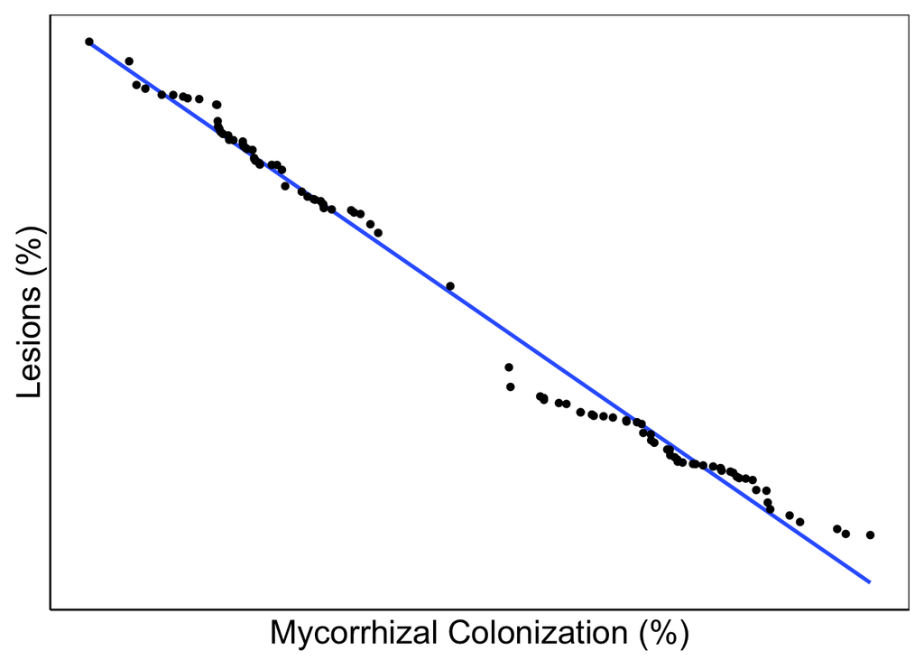

### Hypothesis 2

A. petiolata invasion reduces mycorrhizal colonization and increases pathogen colonization and herbivory

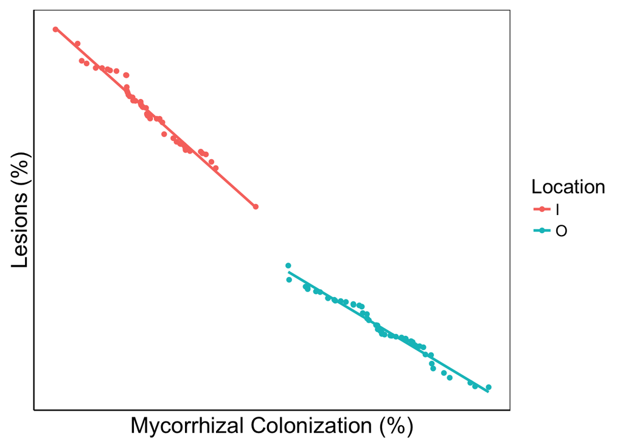

### Hypothesis 3

Efficiency of mycorrhizal protection is reduced in the presence of A. petiolata

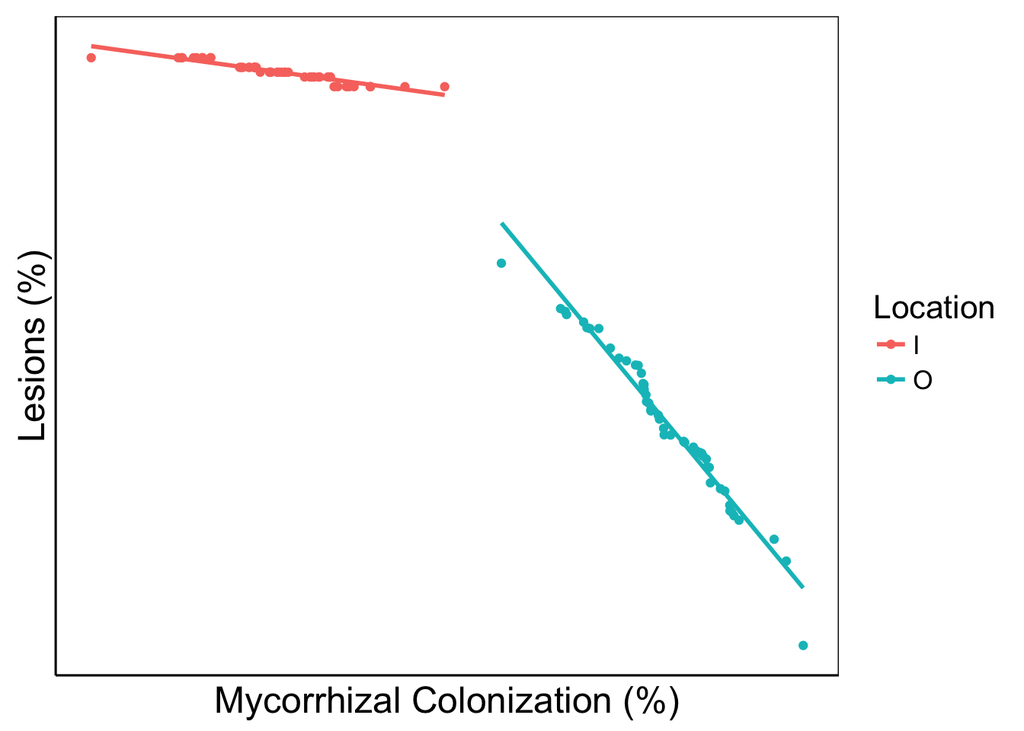

## Molecular data Hypothesis

### Hypothesis 1

A. petiolata invasion changes the diversity of mycorrhizal and other fungal species present in the soil.

I will find that the molecular data from the soil extraction supports this claim by having a reduced biodiversity and abundance of mycorrhiza in samples taken inside A. petiolata populations.

### Hypothesis 2

There will be a negative correlation between mycorrhizal and fungal pathogen diversity.

# Histology data Analysis

## Hypothesis 1: Lesion ~ Mycorriza

### Co-occurence data

```r
# calculating the r
indivCODE <- unique(fdata$indiv2)
dfcorr <-data.frame(indivCODE=c(0),r=c(0))
for (i in 1:length(indivCODE)){
  dat1<-NULL
  dat1<-filter(fdata, fdata$indiv2==indivCODE[i])
  dfcorr[i,1] <- indivCODE[i]
  dfcorr[i,2] <- cor(as.numeric(dat1$Mycorrhiza),as.numeric(dat1$Lesion))
}
```

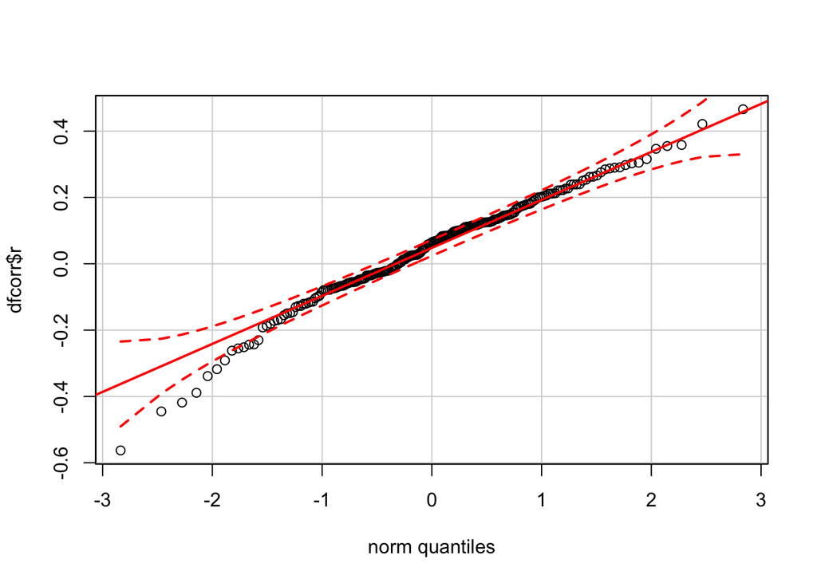

```r
dfcorr %>% drop_na()->dfcorr

#Normal?
car::qqp(dfcorr$r, "norm")
```

```r
shapiro.test(dfcorr$r)
```

```
##
##  Shapiro-Wilk normality test
##
## data:  dfcorr$r
## W = 0.98142, p-value = 0.005557
```

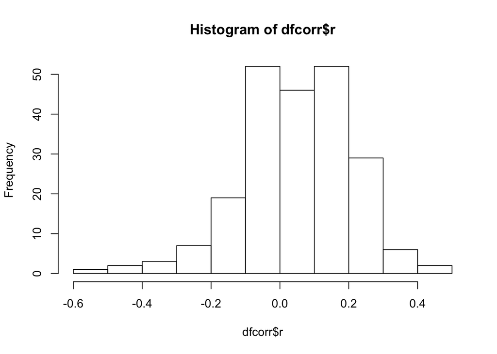

```r
hist(dfcorr$r)
```

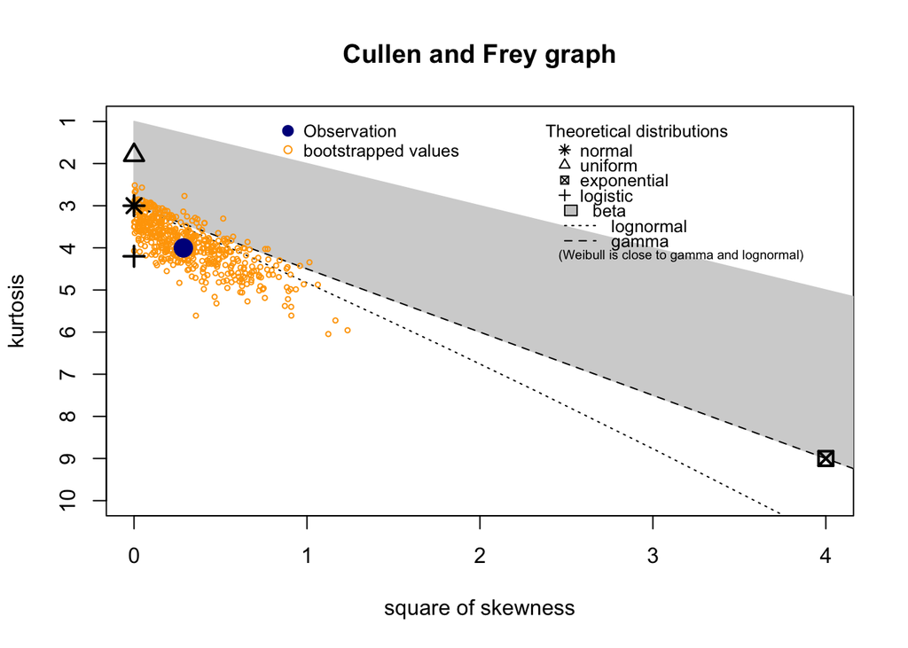

```
## summary statistics
## ------
## min:  -0.5626982   max:  0.4658362
## median:  0.06486581
## mean:  0.04623504
## estimated sd:  0.1594355
## estimated skewness:  -0.5341225
## estimated kurtosis:  4.002332
```

```r
# Cannot be normal because it is only between -1 and 1 and our mean is at 0.
descdist(dfcorr$r, discrete = FALSE, boot = 500)
```

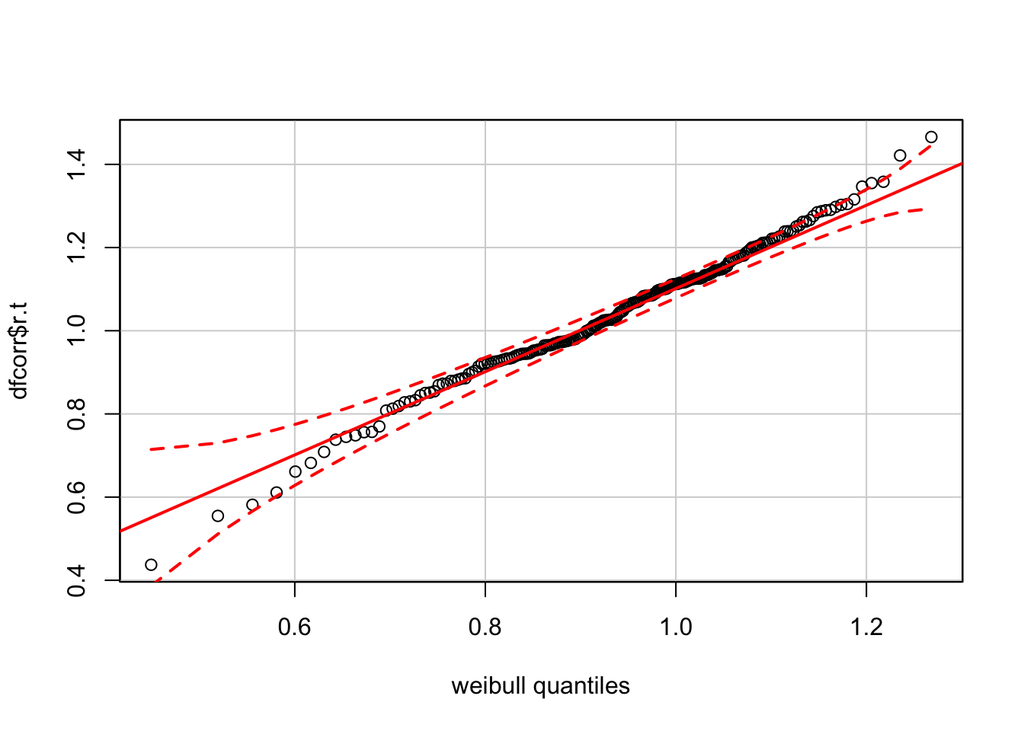

```r
# weibull when transformed to be positive?
dfcorr$r.t <- dfcorr$r+1
fit.weibull <- fitdist(dfcorr$r.t, "weibull")
car::qqp(dfcorr$r.t, "weibull", shape = fit.weibull$estimate[[1]])
```

```r
dfcorr$pop <- gsub("^([0-9]+)[I,O][A-Z]+.*","\\1",dfcorr$indivCODE)
dfcorr$location <- gsub("^[0-9]+([I,O])[A-Z]+.*","\\1",dfcorr$indivCODE)
dfcorr$species <- sub("^[0-9]+[I,O]([A-Z]+).*","\\1",dfcorr$indivCODE)
dfcorr$location <- as.factor(dfcorr$location)
dfcorr$species <- as.factor(dfcorr$species)
dfcorr$pop <- as.factor(dfcorr$pop)

meanR<-mean(dfcorr$r)
SEMR<-sd(dfcorr$r)/sqrt(length(dfcorr$r))
UCI<- meanR+SEMR*1.96
LCI<- meanR-SEMR*1.96
mean(filter(dfcorr, dfcorr$location=="I")$r)
```

```
## [1] 0.03648494
```

```r
mean(filter(dfcorr, dfcorr$location=="O")$r)
```

```
## [1] 0.05505253
```

```r
baysian_corrGLMM <- brm(r.t ~ location * species + (1|pop), data=dfcorr, family = weibull(link="log"), control = list(adapt_delta = 0.9))
```

[output not shown]

[output cut: 40 more lines]

[output not shown]

```r
baysian_corrGLMM2 <- brm(r.t ~ location + species + (1|pop), data=dfcorr, family = weibull(link="log"), control = list(adapt_delta = 0.9))
```

[output not shown]

[output cut: 40 more lines]

[output not shown]

```r
baysian_corrGLMM3 <- brm(r.t ~ location + (1|pop), data=dfcorr, family = weibull(link="log"), control = list(adapt_delta = 0.9))
```

[output not shown]

[output cut: 40 more lines]

[output not shown]

```r
baysian_corrGLMM_NULL <- brm(r.t ~ 1 + (1|pop), data=dfcorr, family = weibull(link="log"), control = list(adapt_delta = 0.9))
```

[output not shown]

[output cut: 40 more lines]

[output not shown]

```r
waic.BCG_1<-waic(baysian_corrGLMM)
waic.BCG_2<-waic(baysian_corrGLMM2)
waic.BCG_3<-waic(baysian_corrGLMM3)
waic.BCG_NULL<-waic(baysian_corrGLMM_NULL)
compare(waic.BCG_1,waic.BCG_2) #positive means second is better
```

```
## elpd_diff        se
##       1.8       2.2
```

```r
compare(waic.BCG_2,waic.BCG_3) #negative means first is better
```

```
## elpd_diff        se
##      -5.1       4.7
```

```r
compare(waic.BCG_2,waic.BCG_NULL) #negative means first is better
```

```
## elpd_diff        se
##      -4.3       4.7
```

```r
summary(baysian_corrGLMM2)
```

```
##  Family: weibull
##   Links: mu = log; shape = identity
## Formula: r.t ~ location + species + (1 | pop)
##    Data: dfcorr (Number of observations: 219)
## Samples: 4 chains, each with iter = 2000; warmup = 1000; thin = 1;
##          total post-warmup samples = 4000
##     ICs: LOO = NA; WAIC = NA; R2 = NA
##
## Group-Level Effects:
## ~pop (Number of levels: 11)
##               Estimate Est.Error l-95% CI u-95% CI Eff.Sample Rhat
## sd(Intercept)     0.11      0.09     0.00     0.33       1532 1.00
##
## Population-Level Effects:
##           Estimate Est.Error l-95% CI u-95% CI Eff.Sample Rhat
## Intercept     0.76      0.21     0.36     1.20       1714 1.00
## locationO     0.09      0.14    -0.18     0.36       4000 1.00
## speciesCL     0.56      0.26     0.06     1.06       1865 1.00
## speciesGA    -0.30      0.24    -0.77     0.17       1835 1.00
## speciesGR     0.39      0.34    -0.24     1.08       2329 1.00
## speciesMR     0.25      0.27    -0.26     0.79       1881 1.00
## speciesSC    -0.14      0.23    -0.59     0.30       1738 1.00
##
## Family Specific Parameters:
##       Estimate Est.Error l-95% CI u-95% CI Eff.Sample Rhat
## shape     8.10      0.43     7.29     8.97       2883 1.00
##
## Samples were drawn using sampling(NUTS). For each parameter, Eff.Sample
## is a crude measure of effective sample size, and Rhat is the potential
## scale reduction factor on split chains (at convergence, Rhat = 1).
```

```r
bayes_R2(baysian_corrGLMM2)
```

```
##      Estimate  Est.Error    2.5%ile  97.5%ile
## R2 0.08517583 0.02681794 0.03708259 0.1411388
```

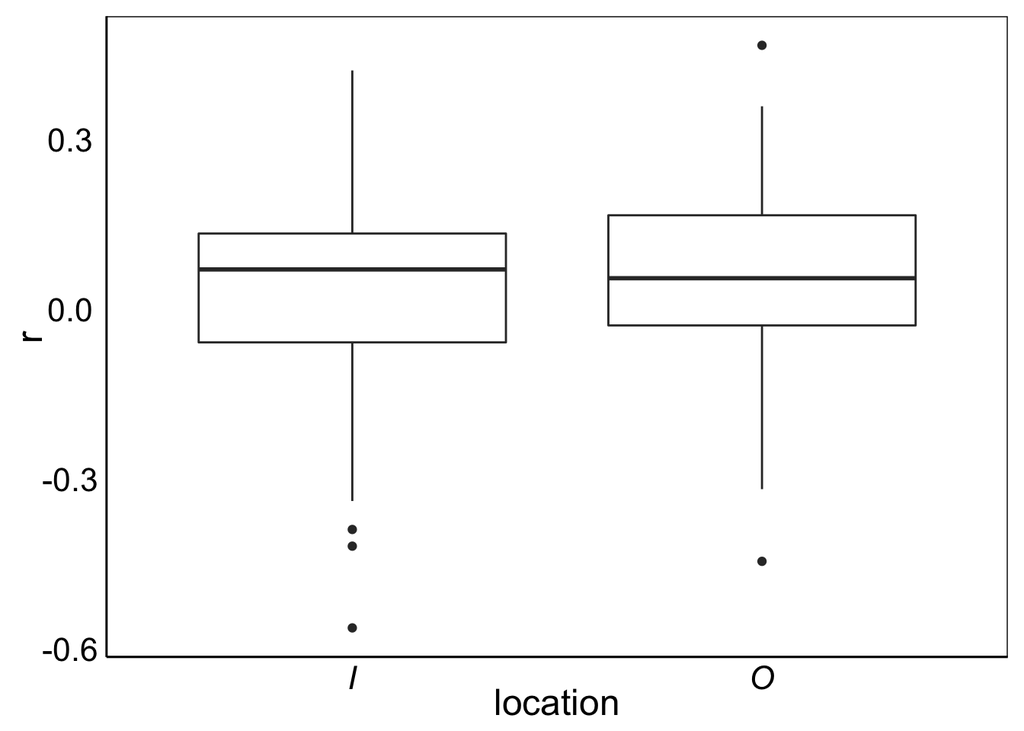

```r
ggplot(dfcorr, aes(y=r,x=location))+geom_boxplot()+theme_simple()
```

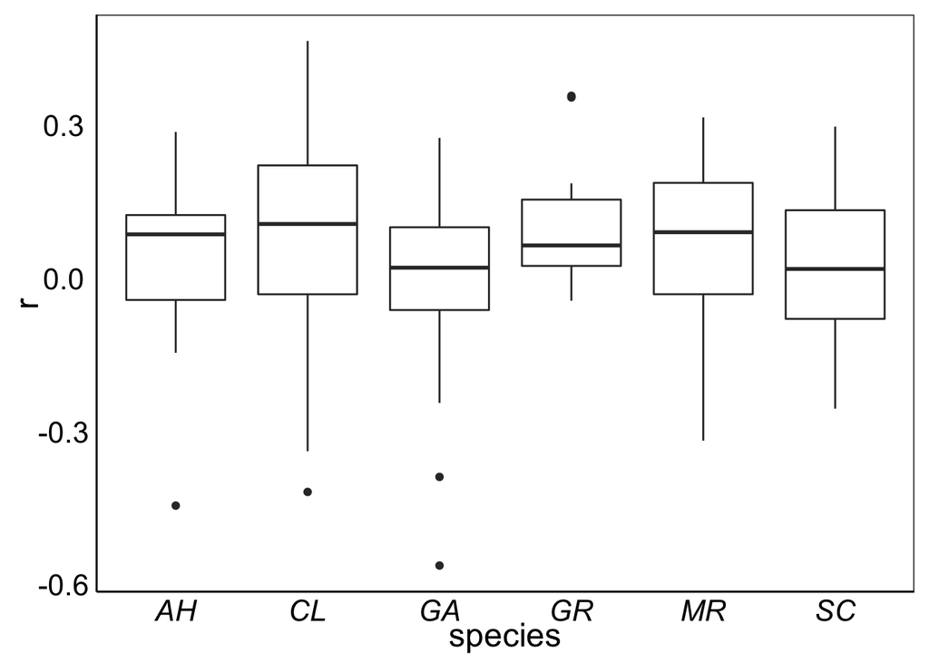

```r
ggplot(dfcorr, aes(y=r,x=species))+geom_boxplot()+theme_simple()
```

### Totals data

```r
# model
GLMMmyc_lesion <- glmer(binlesion ~ None.Myc * species + (1 | pop) , data = ndatas,family = binomial(link = "logit"))
summary(GLMMmyc_lesion)
```

```
## Generalized linear mixed model fit by maximum likelihood (Laplace
##   Approximation) [glmerMod]
##  Family: binomial  ( logit )
## Formula: binlesion ~ None.Myc * species + (1 | pop)
##    Data: ndatas
##
##      AIC      BIC   logLik deviance df.resid
##   5388.9   5433.4  -2681.5   5362.9      213
##
## Scaled residuals:
##     Min      1Q  Median      3Q     Max
## -7.9159 -3.2800 -0.7426  2.8805 11.6817
##
## Random effects:
##  Groups Name        Variance Std.Dev.
##  pop    (Intercept) 0.07038  0.2653
## Number of obs: 226, groups:  pop, 11
##
## Fixed effects:
##                     Estimate Std. Error z value Pr(>|z|)
## (Intercept)        -0.750276   0.090719  -8.270  < 2e-16 ***
## None.Myc           -0.017781   0.038118  -0.466 0.640866
## speciesCL           0.415585   0.056183   7.397 1.39e-13 ***
## speciesGA           0.444280   0.053486   8.306  < 2e-16 ***
## speciesGR           0.266576   0.073678   3.618 0.000297 ***
## speciesMR           0.146355   0.057804   2.532 0.011344 *
## speciesSC           0.007849   0.051574   0.152 0.879040
## None.Myc:speciesCL  0.156587   0.048414   3.234 0.001219 **
## None.Myc:speciesGA  0.191932   0.050731   3.783 0.000155 ***
## None.Myc:speciesGR  0.338206   0.069696   4.853 1.22e-06 ***
## None.Myc:speciesMR  0.063131   0.053541   1.179 0.238360
## None.Myc:speciesSC  0.210590   0.051242   4.110 3.96e-05 ***
## ---
## Signif. codes:  0 '***' 0.001 '**' 0.01 '*' 0.05 '.' 0.1 ' ' 1
##
## Correlation of Fixed Effects:
##             (Intr) Nn.Myc spcsCL spcsGA spcsGR spcsMR spcsSC N.M:CL N.M:GA
## None.Myc    -0.134
## speciesCL   -0.369  0.213
## speciesGA   -0.385  0.223  0.649
## speciesGR   -0.279  0.160  0.466  0.500
## speciesMR   -0.340  0.207  0.572  0.614  0.438
## speciesSC   -0.381  0.233  0.627  0.660  0.477  0.588
## Nn.Myc:spCL  0.098 -0.786 -0.235 -0.155 -0.110 -0.155 -0.171
## Nn.Myc:spGA  0.094 -0.750 -0.141 -0.235 -0.116 -0.146 -0.169  0.593
## Nn.Myc:spGR  0.086 -0.551 -0.142 -0.151 -0.111 -0.128 -0.145  0.431  0.406
## Nn.Myc:spMR  0.090 -0.711 -0.144 -0.148 -0.092 -0.111 -0.159  0.560  0.534
## Nn.Myc:spSC  0.116 -0.750 -0.191 -0.195 -0.145 -0.169 -0.045  0.589  0.555
##             N.M:GR N.M:MR
## None.Myc
## speciesCL
## speciesGA
## speciesGR
## speciesMR
## speciesSC
## Nn.Myc:spCL
## Nn.Myc:spGA
## Nn.Myc:spGR
## Nn.Myc:spMR  0.394
## Nn.Myc:spSC  0.429  0.527
```

```r
options(na.action="na.fail")
dredge(GLMMmyc_lesion)
```

```
## Fixed term is "(Intercept)"
```

|  | (Intercept) | None.Myc | species | None.Myc:species | df | logLik | AICc | delta | weight |
| --- | --- | --- | --- | --- | --- | --- | --- | --- | --- |
| 8 | -0.7502755 | -0.01778141 | + | + | 13 | -2681.458 | 5390.633 | 0.00000 | 9.999957e-01 |
| 4 | -0.8089456 | 0.12986872 | + | NA | 8 | -2699.344 | 5415.353 | 24.71955 | 4.287610e-06 |
| 3 | -0.7648436 | NA | + | NA | 7 | -2738.342 | 5491.198 | 100.56483 | 1.454195e-22 |
| 2 | -0.5563722 | 0.16023096 | NA | NA | 3 | -2798.956 | 5604.020 | 213.38687 | 4.609230e-47 |
| 1 | -0.5552463 | NA | NA | NA | 2 | -2863.353 | 5730.759 | 340.12615 | 1.388488e-74 |

```r
r.squaredGLMM(GLMMmyc_lesion)
```

```
## The result is correct only if all data used by the model has not changed since model was fitted.
```

```
##        R2m        R2c
## 0.02739802 0.04008648
```

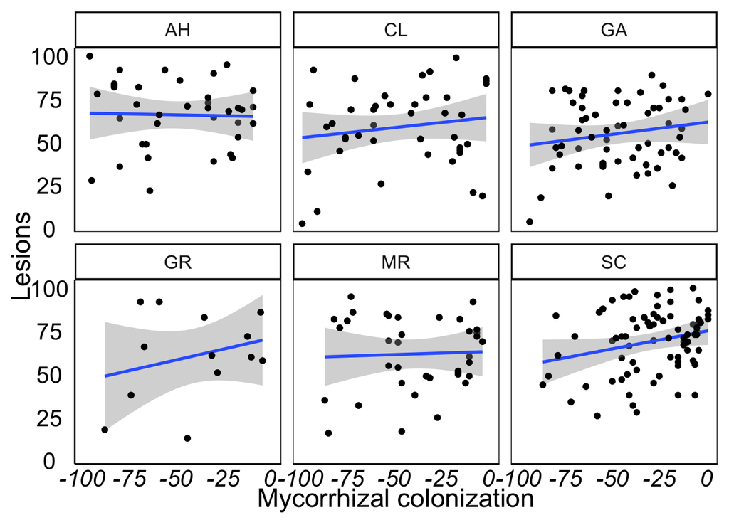

```r
# will need to change this ASAP

ggplot(data = ndata,aes(x = 1-None.Myc, y = 100-None.Path))+
  stat_summary(fun.y=mean, geom="point")+
  geom_smooth(method = "lm")+
  geom_point()+
  theme_simple()+
  facet_wrap("species")+
  labs(x = "Mycorrhizal colonization", y="Lesions")
```

**SUMMARY:**

Is the totals the same as the corr data?

if not what has change? what does it mean biologically: Same/less path=mycorrhiza defend NotSame/less path=mycorrhizal defence is not related to colonization. if theres not an effect then maybe it has more to do with the species composition than the actual mycorrhizal colonization, Thats why we will test pathogen colonization alone (without myc = H2)

## Hypothesis 2: Mycorrhiza & Lesion ~ invasion

### Does location impact the effect of myc on lesion?

```r
GLMMmyc_lesion_loc <- glmer(binlesion ~ None.Myc * location * species + (1 | pop), data = ndatas, family = binomial(link = "logit"))
summary(GLMMmyc_lesion_loc)
```

```
## Generalized linear mixed model fit by maximum likelihood (Laplace
##   Approximation) [glmerMod]
##  Family: binomial  ( logit )
## Formula: binlesion ~ None.Myc * location * species + (1 | pop)
##    Data: ndatas
##
##      AIC      BIC   logLik deviance df.resid
##   5185.5   5271.0  -2567.7   5135.5      201
##
## Scaled residuals:
##     Min      1Q  Median      3Q     Max
## -7.6366 -3.2043 -0.3462  2.6760 13.6450
##
## Random effects:
##  Groups Name        Variance Std.Dev.
##  pop    (Intercept) 0.0698   0.2642
## Number of obs: 226, groups:  pop, 11
##
## Fixed effects:
##                               Estimate Std. Error z value Pr(>|z|)
## (Intercept)                  -0.725383   0.100890  -7.190 6.49e-13 ***
## None.Myc                     -0.062764   0.054987  -1.141 0.253688
## locationO                    -0.068081   0.081316  -0.837 0.402458
## speciesCL                     0.200476   0.081638   2.456 0.014063 *
## speciesGA                     0.296660   0.077883   3.809 0.000139 ***
## speciesGR                    -1.181296   0.193649  -6.100 1.06e-09 ***
## speciesMR                     0.277361   0.084158   3.296 0.000982 ***
## speciesSC                    -0.021562   0.073106  -0.295 0.768042
## None.Myc:locationO            0.093031   0.080266   1.159 0.246440
## None.Myc:speciesCL            0.324299   0.071788   4.517 6.26e-06 ***
## None.Myc:speciesGA            0.189403   0.072737   2.604 0.009216 **
## None.Myc:speciesGR           -0.300771   0.187873  -1.601 0.109393
## None.Myc:speciesMR            0.255496   0.077895   3.280 0.001038 **
## None.Myc:speciesSC            0.101743   0.070113   1.451 0.146743
## locationO:speciesCL           0.398803   0.106396   3.748 0.000178 ***
## locationO:speciesGA           0.301929   0.101835   2.965 0.003028 **
## locationO:speciesGR           1.889287   0.212942   8.872  < 2e-16 ***
## locationO:speciesMR          -0.260917   0.111010  -2.350 0.018754 *
## locationO:speciesSC           0.143608   0.103149   1.392 0.163850
## None.Myc:locationO:speciesCL -0.282839   0.100392  -2.817 0.004842 **
## None.Myc:locationO:speciesGA -0.003347   0.105512  -0.032 0.974693
## None.Myc:locationO:speciesGR  0.463051   0.207868   2.228 0.025906 *
## None.Myc:locationO:speciesMR -0.384191   0.109499  -3.509 0.000450 ***
## None.Myc:locationO:speciesSC  0.233745   0.102953   2.270 0.023183 *
## ---
## Signif. codes:  0 '***' 0.001 '**' 0.01 '*' 0.05 '.' 0.1 ' ' 1
```

```
##
## Correlation matrix not shown by default, as p = 24 > 12.
## Use print(x, correlation=TRUE)  or
##   vcov(x)     if you need it
```

```r
emm<-emmeans(GLMMmyc_lesion_loc, list(~None.Myc| species | location, ~None.Myc| location), type = "response" )
```

```
## NOTE: Results may be misleading due to involvement in interactions
```

```r
summary(emm)
```

```
## $`emmeans of None.Myc, location | species`
## species = AH:
##      None.Myc location      prob         SE df  asymp.LCL asymp.UCL
##  1.058488e-16 I        0.3262087 0.02217532 NA 0.28432176 0.3710671
##  1.058488e-16 O        0.3114255 0.02097601 NA 0.27186461 0.3539447
##
## species = CL:
##      None.Myc location      prob         SE df  asymp.LCL asymp.UCL
##  1.058488e-16 I        0.3717055 0.02222786 NA 0.32927810 0.4162074
##  1.058488e-16 O        0.4516058 0.02288001 NA 0.40727139 0.4967219
##
## species = GA:
##      None.Myc location      prob         SE df  asymp.LCL asymp.UCL
##  1.058488e-16 I        0.3944313 0.02175155 NA 0.35269620 0.4377651
##  1.058488e-16 O        0.4514349 0.02239380 NA 0.40803107 0.4955905
##
## species = GR:
##      None.Myc location      prob         SE df  asymp.LCL asymp.UCL
##  1.058488e-16 I        0.1293544 0.02255808 NA 0.09118441 0.1803321
##  1.058488e-16 O        0.4786449 0.02657122 NA 0.42698389 0.5307668
##
## species = MR:
##      None.Myc location      prob         SE df  asymp.LCL asymp.UCL
##  1.058488e-16 I        0.3898311 0.02331380 NA 0.34521822 0.4363672
##  1.058488e-16 O        0.3149625 0.02075782 NA 0.27576180 0.3569890
##
## species = SC:
##      None.Myc location      prob         SE df  asymp.LCL asymp.UCL
##  1.058488e-16 I        0.3214874 0.01942629 NA 0.28465376 0.3606841
##  1.058488e-16 O        0.3381795 0.02091737 NA 0.29847025 0.3803078
##
## Confidence level used: 0.95
## Intervals are back-transformed from the logit scale
##
## $`emmeans of None.Myc | location`
## location = I:
##      None.Myc      prob         SE df asymp.LCL asymp.UCL
##  1.058488e-16 0.3107155 0.01873775 NA 0.2752289 0.3485770
##
## location = O:
##      None.Myc      prob         SE df asymp.LCL asymp.UCL
##  1.058488e-16 0.3887098 0.01966447 NA 0.3509329 0.4278726
##
## Results are averaged over the levels of: species
## Confidence level used: 0.95
## Intervals are back-transformed from the logit scale
```

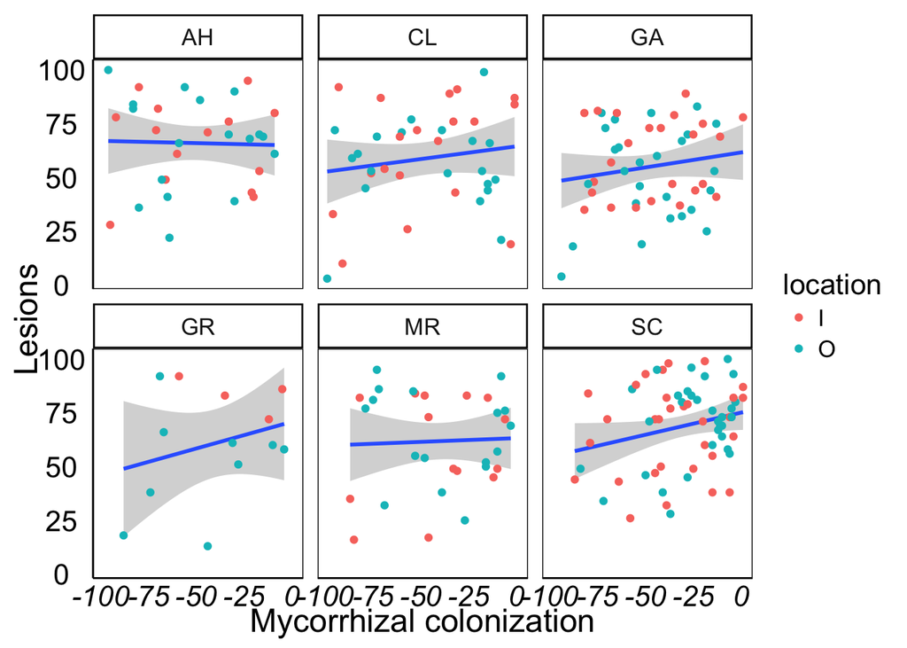

```r
ggplot(data = ndata,aes(x = 1-None.Myc, y = 100-None.Path))+
  geom_smooth(method = "lm")+
  geom_point(aes(color=location))+
  theme_simple()+
  facet_wrap("species")+
  labs(x = "Mycorrhizal colonization", y="Lesions")
```

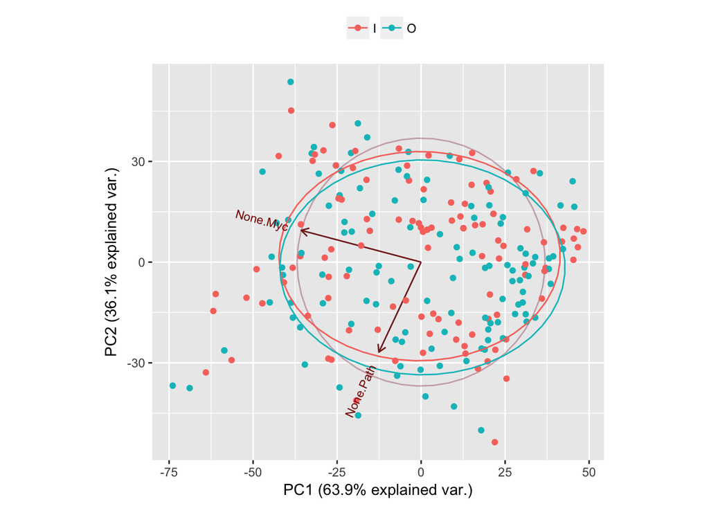

```r
pca <- prcomp(ndata[,c(5,9)])
location <- ndata[,13]
library(ggbiplot)
g <- ggbiplot(pca, obs.scale = 1, var.scale = 1,
                groups = location, ellipse = TRUE,
                circle = TRUE)
g <- g + scale_color_discrete(name = '')
g <- g + theme(legend.direction = 'horizontal',
                 legend.position = 'top')
print(g)
```

### Does location impact lesion alone?

```r
glmerLESION_disp <- glmer (binlesion ~ location * species + (1|pop) + (1|indiv), data = ndatas, family = binomial(link="logit"))
summary(glmerLESION_disp)
```

```
## Generalized linear mixed model fit by maximum likelihood (Laplace
##   Approximation) [glmerMod]
##  Family: binomial  ( logit )
## Formula: binlesion ~ location * species + (1 | pop) + (1 | indiv)
##    Data: ndatas
##
##      AIC      BIC   logLik deviance df.resid
##   2011.7   2059.6   -991.8   1983.7      212
##
## Scaled residuals:
##      Min       1Q   Median       3Q      Max
## -1.53231 -0.13210 -0.00971  0.11216  1.14859
##
## Random effects:
##  Groups Name        Variance Std.Dev.
##  indiv  (Intercept) 1.11959  1.0581
##  pop    (Intercept) 0.06426  0.2535
## Number of obs: 226, groups:  indiv, 226; pop, 11
##
## Fixed effects:
##                     Estimate Std. Error z value Pr(>|z|)
## (Intercept)         -0.85482    0.30710  -2.784  0.00538 **
## locationO           -0.10392    0.39475  -0.263  0.79235
## speciesCL            0.26989    0.39300   0.687  0.49225
## speciesGA            0.38852    0.37584   1.034  0.30127
## speciesGR           -0.88023    0.62967  -1.398  0.16214
## speciesMR            0.38516    0.41882   0.920  0.35776
## speciesSC           -0.09661    0.35549  -0.272  0.78581
## locationO:speciesCL  0.45477    0.52759   0.862  0.38870
## locationO:speciesGA  0.47505    0.50259   0.945  0.34456
## locationO:speciesGR  1.77188    0.77503   2.286  0.02224 *
## locationO:speciesMR -0.28686    0.55694  -0.515  0.60651
## locationO:speciesSC -0.02068    0.48262  -0.043  0.96582
## ---
## Signif. codes:  0 '***' 0.001 '**' 0.01 '*' 0.05 '.' 0.1 ' ' 1
##
## Correlation of Fixed Effects:
##             (Intr) loctnO spcsCL spcsGA spcsGR spcsMR spcsSC lcO:CL lcO:GA
## locationO   -0.703
## speciesCL   -0.741  0.551
```

[output cut: 8 more lines]

```
## lctnO:spcSC  0.575 -0.818 -0.450 -0.473 -0.283 -0.428 -0.721  0.612  0.643
##             lcO:GR lcO:MR
## locationO
## speciesCL
## speciesGA
## speciesGR
## speciesMR
## speciesSC
## lctnO:spcCL
## lctnO:spcGA
## lctnO:spcGR
## lctnO:spcMR  0.366
## lctnO:spcSC  0.419  0.580
## convergence code: 0
## Model failed to converge with max|grad| = 0.00135513 (tol = 0.001, component 1)
```

```r
options(na.action="na.fail")
dredge(glmerLESION_disp)
```

```
## Fixed term is "(Intercept)"
```

|  | (Intercept) | location | species | location:species | df | logLik | AICc | delta | weight |
| --- | --- | --- | --- | --- | --- | --- | --- | --- | --- |
| 3 | -0.9119581 | NA | + | NA | 8 | -996.7655 | 2010.195 | 0.000000 | 0.54706869 |
| 4 | -0.9780389 | + | + | NA | 9 | -996.4174 | 2011.668 | 1.473617 | 0.26184845 |
| 8 | -0.8548199 | + | + | + | 14 | -991.8425 | 2013.676 | 3.481011 | 0.09597317 |
| 1 | -0.6667444 | NA | NA | NA | 3 | -1004.2022 | 2014.513 | 4.318047 | 0.06315240 |
| 2 | -0.7343567 | + | NA | NA | 4 | -1003.8470 | 2015.875 | 5.680349 | 0.03195728 |

```r
r.squaredGLMM(glmerLESION_disp)
```

```
##        R2m        R2c
## 0.03076813 0.04469034
```

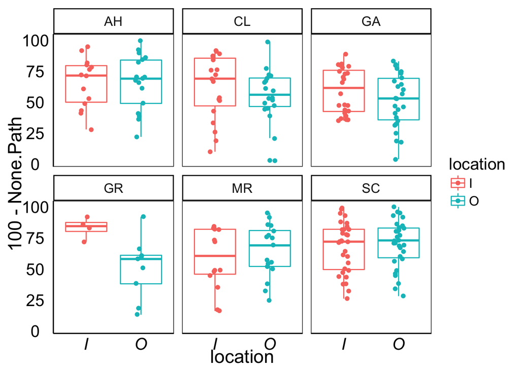

```r
ggplot(aes(x = location, y = 100-None.Path, color=location), data=ndata)+
  geom_boxplot()+
  geom_jitter(width=0.1)+
  facet_wrap("species")+
  theme_simple()
```

### Does location impact mycorrhiza alone?

```r
glmerMYC_disp <- glmer (binmycorr ~ location * species + (1|pop) + (1|indiv), data = ndata, family = binomial(link="logit"))
summary(glmerMYC_disp)
```

```
## Generalized linear mixed model fit by maximum likelihood (Laplace
##   Approximation) [glmerMod]
##  Family: binomial  ( logit )
## Formula: binmycorr ~ location * species + (1 | pop) + (1 | indiv)
##    Data: ndata
##
##      AIC      BIC   logLik deviance df.resid
##   2073.3   2121.2  -1022.7   2045.3      212
##
## Scaled residuals:
##      Min       1Q   Median       3Q      Max
## -1.35863 -0.12130  0.01523  0.09795  1.40036
##
## Random effects:
##  Groups Name        Variance  Std.Dev.
##  indiv  (Intercept) 2.062e+00 1.4361234
##  pop    (Intercept) 1.044e-08 0.0001022
## Number of obs: 226, groups:  indiv, 226; pop, 11
##
## Fixed effects:
##                      Estimate Std. Error z value Pr(>|z|)
## (Intercept)          0.121220   0.390387   0.310   0.7562
## locationO           -0.008745   0.526879  -0.017   0.9868
## speciesCL           -0.200766   0.515746  -0.389   0.6971
## speciesGA           -0.375379   0.491194  -0.764   0.4447
## speciesGR           -1.324367   0.829848  -1.596   0.1105
## speciesMR           -0.505583   0.551771  -0.916   0.3595
## speciesSC           -0.954255   0.471189  -2.025   0.0428 *
## locationO:speciesCL  0.053276   0.706272   0.075   0.9399
## locationO:speciesGA  0.233201   0.669292   0.348   0.7275
## locationO:speciesGR  0.990565   1.025133   0.966   0.3339
## locationO:speciesMR -0.245112   0.745205  -0.329   0.7422
## locationO:speciesSC -0.457001   0.645298  -0.708   0.4788
## ---
## Signif. codes:  0 '***' 0.001 '**' 0.01 '*' 0.05 '.' 0.1 ' ' 1
##
## Correlation of Fixed Effects:
##             (Intr) loctnO spcsCL spcsGA spcsGR spcsMR spcsSC lcO:CL lcO:GA
## locationO   -0.741
## speciesCL   -0.757  0.561
## speciesGA   -0.795  0.589  0.602
## speciesGR   -0.470  0.349  0.356  0.374
## speciesMR   -0.708  0.524  0.536  0.562  0.333
## speciesSC   -0.829  0.614  0.627  0.659  0.390  0.586
## lctnO:spcCL  0.553 -0.746 -0.730 -0.439 -0.260 -0.391 -0.458
## lctnO:spcGA  0.583 -0.787 -0.442 -0.734 -0.274 -0.413 -0.483  0.587
## lctnO:spcGR  0.381 -0.514 -0.288 -0.303 -0.809 -0.269 -0.316  0.383  0.405
## lctnO:spcMR  0.524 -0.707 -0.396 -0.416 -0.246 -0.740 -0.434  0.527  0.557
## lctnO:spcSC  0.605 -0.816 -0.458 -0.481 -0.285 -0.428 -0.730  0.609  0.643
##             lcO:GR lcO:MR
## locationO
## speciesCL
## speciesGA
## speciesGR
## speciesMR
## speciesSC
## lctnO:spcCL
## lctnO:spcGA
## lctnO:spcGR
## lctnO:spcMR  0.363
## lctnO:spcSC  0.420  0.577
```

```r
options(na.action="na.fail")
dredge(glmerMYC_disp)
```

```
## Fixed term is "(Intercept)"
```

|  | (Intercept) | location | species | location:species | df | logLik | AICc | delta | weight |
| --- | --- | --- | --- | --- | --- | --- | --- | --- | --- |
| 3 | 0.1165554 | NA | + | NA | 8 | -1024.316 | 2065.296 | 0.000000 | 0.727837979 |
| 4 | 0.1480145 | + | + | NA | 9 | -1024.274 | 2067.381 | 2.085678 | 0.256528423 |
| 1 | -0.4190789 | NA | NA | NA | 3 | -1034.116 | 2074.340 | 9.044620 | 0.007907156 |
| 8 | 0.1212204 | + | + | + | 14 | -1022.659 | 2075.309 | 10.013844 | 0.004870305 |
| 2 | -0.3982289 | + | NA | NA | 4 | -1034.098 | 2076.377 | 11.081217 | 0.002856137 |

```r
r.squaredGLMM(glmerMYC_disp)
```

```
##       R2m       R2c
## 0.0410656 0.0410656
```

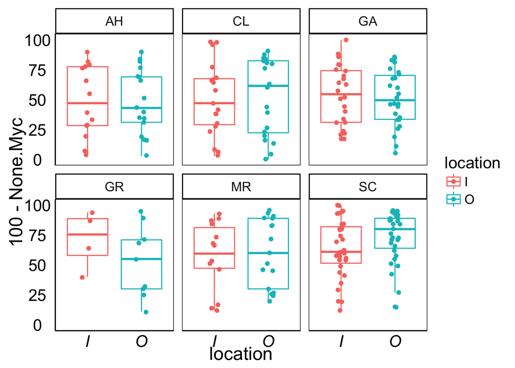

```r
ggplot(aes(x = location, y = 100-None.Myc, color=location), data=ndata)+
  geom_boxplot()+
  geom_jitter(width=0.1)+
  facet_wrap("species")+
  theme_simple()
```

## Hypothesis 3: Lesion ~ Mycorriza * invasion

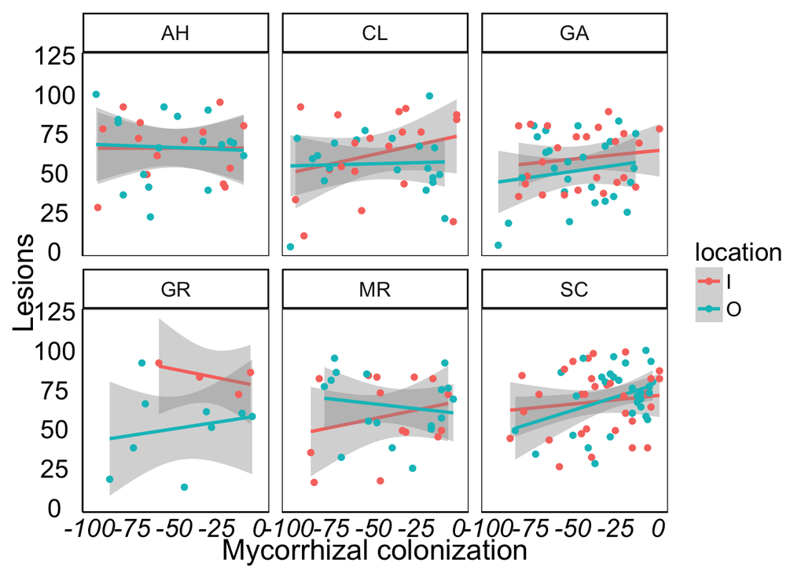

```r
ggplot(data = ndata,aes(x = 1-None.Myc, y = 100-None.Path, color=location))+
  geom_smooth(method = "lm")+
  geom_point()+
  theme_simple()+
  facet_wrap("species")+
  labs(x = "Mycorrhizal colonization", y="Lesions")
```

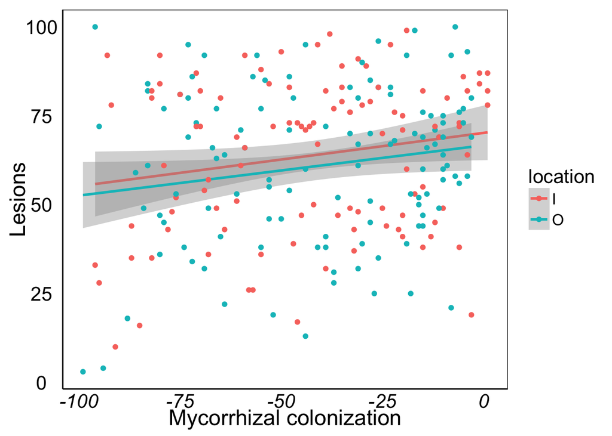

```r
ggplot(data = ndata,aes(x = 1-None.Myc, y = 100-None.Path, color=location))+
  geom_smooth(method = "lm")+
  geom_point()+
  theme_simple()+
  labs(x = "Mycorrhizal colonization", y="Lesions")
```

# Molecular data Analysis

## Hypothesis 1: Mycorrhiza_div ~ invasion

## Hypothesis 2: Mycorrhiza_div ~ Pathoge_div